# Bayesian Posterior

I am going to demonstrate MCMC using the Metropolis-Hastings algorithm as described on page 359 of Professor Michael Lavine’s book Introduction to Statistical Thought. You can access this free book under the ‘Resources’ section of the class syllabus. This book is an excellent resource for Bayesians statistics and statistics generally. I have included a screen shot below:

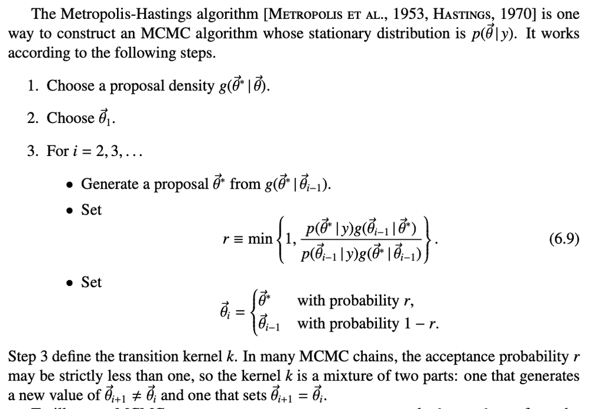

Metropolis-Hastings Algorithm

y~normal(mu, sd) mu<-bo + b1*x

bo~normal(0,sd=100) b1~normal(0,sd=100) sd~gamma(1,1/100)

Here is the basic algorithm:

1. Choose a proposal density g(thetaStar | theta)
2. For each component of the parameter vector (lets call this parameter theta), generate a proposed parameter. Lets call this thetaStar
3. Calculate numerator <- p(thetaStar|y)*g(theta|thetaStar)
4. Calculate denominator <- p(theta|y)*g(thetaStar|theta)
5. q<-numerator/denominator
6. Set r -> min(1, q)
7. Set theta -> thetaStar with probability r else theta
8. Repeat this for all parameters in the parameter set.
9. Repeat all sequence of steps many times.

First, I generate some artificial data. This allows us to try to recapture the model parameters. If we are successful at recapturing the model parameters, then this gives us some confidence that our code is working.

We generate a 1000 data points from a linear relationship with intercept (bo) = 1.0, slope (b1) = 0.2, and sd = 1.5.

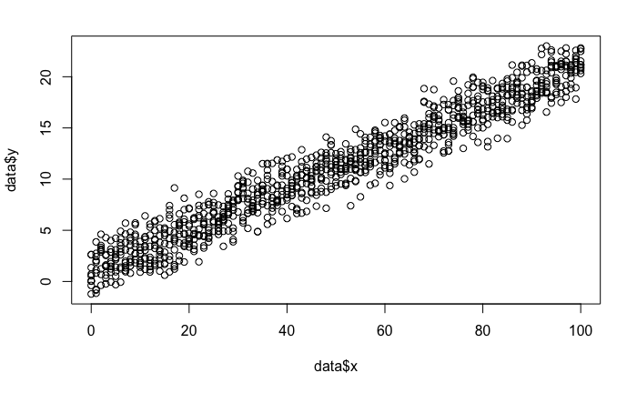

```r
nReps<-10
x<-seq(from=0,to=100,by=1)
x<-rep(x,nReps)
b0<-1.0; b1<-0.2
ymean<-b0+b1*x
y<-rnorm(n=length(ymean),mean=ymean,sd=1.5)
data<-data.frame(x,y)
rm(x,y)
plot(data$x,data$y)
```

Log Likelihood

```r
li_reg_bb<-function(pars,data)
{
    a<-pars[1]      #intercept
    b<-pars[2]      #slope
    sd_e<-pars[3]   #error (residuals)
    if(sd_e<=0){return(NaN)}
    pred <- a + b * data[,1]
    log_likelihood<-sum( dnorm(data[,2],pred,sd_e, log=TRUE) )
    # prior<- prior_reg(pars)
    return(log_likelihood)
}
```

In this model, we have hardcoded the priors in the function below: The prior on the intercept and slope is normal(0,100) and the prior on the sd is gamma(1, 1/100)

Log Prior Probability

```r
prior_reg<-function(pars)
{
    a<-pars[1]    # intercept
    b<-pars[2]    # slope
    sd<-pars[3]   # sd

    prior_a<-dnorm(a,0,100,log=TRUE)     ## non-informative (flat) priors on all
    prior_b<-dnorm(b,0,100,log=TRUE)     ## parameters.
    prior_sd<-dgamma(sd,1,1/100,log=TRUE)

    return(prior_a + prior_b + prior_sd)
}
```

Here is what the prior on sd looks like

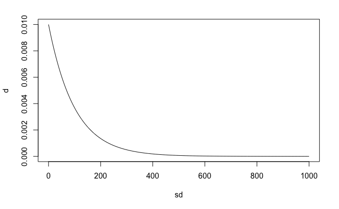

```r
sd<-seq(from=0, to=1000,len=1000)
d<-dgamma(sd,1,1/100,log=F)
plot(sd,d,type='l' )
```

Setting up for sampling

```r
myDebug<-FALSE
parmVect<-c(5.5,2,5)
nIters<-1000000
sdSampler<-0.5
iterMat<-matrix(NA,nrow=nIters+1,ncol=3)
colnames(iterMat)<-c("b0","b1","sd")
iterMat[1,]<-parmVect
```

Running the algorithm…

3. Calculate numerator <- p(thetaStar|y)*g(theta|thetaStar)
4. Calculate denominator <- p(theta|y)*g(thetaStar|theta)

```r
for(i in 1:nIters){

    for(j in seq_along(parmVect)){
        if(myDebug) cat("i= ",i," ; j= ",j,fill=TRUE)
        if(myDebug) cat("Begin loop: parmVect= ",parmVect,fill=TRUE)

      # log p(theta|y) is logLikCurrent + logPriorCurrent
        logLikCurrent<-li_reg_bb(parmVect,data)
        logPriorCurrent<-prior_reg(parmVect)

        if(myDebug) cat("logLikCurrent= ",logLikCurrent," ; logPriorCurrent= ",logPriorCurrent,fill=TRUE)

        if(j<3){ # this sampling for intercept and slope

            parmStar<-rnorm(n=1,mean=parmVect[j],sd=sdSampler)
            # proposed parameter for beta + slope

            # calculating g(thetaStar|theta)
            logThetaStar<-dnorm(parmStar,mean=parmVect[j],sd=sdSampler,log=TRUE)
            # calculating g(theta|thetaStar)
            logTheta<-dnorm(parmVect[j],mean=parmStar,sd=sdSampler,log=TRUE)

            if(myDebug)  {cat("parmStar for b0,b1 = ",parmStar,"logTheta= ",logTheta," ;
                logThetaStar= ",logThetaStar,fill=TRUE)}
        } else{
            parmStar<-rgamma(n=1,shape=2)
            # proposed parameter for beta + slope

            # calculating g(thetaStar|theta)
            logThetaStar<-dgamma(parmStar,shape=2,log=TRUE)
            # calculating g(theta|thetaStar)
            logTheta<-dgamma(parmVect[j],shape=2,log=TRUE)

            if(myDebug) {cat("parmStar for sd = ",parmStar,"logTheta= ",logTheta," ;
                logThetaStar= ",logThetaStar,fill=TRUE)}
        }

        parmVectStar<-parmVect # Current values of parameters are assigned
        parmVectStar[j]<-parmStar
        if(myDebug) cat("parmVectStar = ",parmVectStar,fill=TRUE)

        logLikStar<-li_reg_bb(parmVectStar,data)
        logPriorStar<-prior_reg(parmVectStar)
        if(myDebug) cat("logLikStar= ",logLikStar," ; logPriorStar= ",logPriorStar,fill=TRUE)
        if(myDebug) cat("logTheta= ",logTheta," ; logThetaStar= ",logThetaStar,fill=TRUE)

        numerator<- logLikStar+logPriorStar+logTheta
        denominator<- logLikCurrent+logPriorCurrent+logThetaStar
        qalt<-exp(numerator-denominator)
        q<-exp(logLikStar+logPriorStar+logTheta
               -logLikCurrent-logPriorCurrent-logThetaStar)
        r=min(1, q)

        if(myDebug) cat("r= ",r," ; q= ",q,fill=TRUE)

        if(runif(n=1)<r) parmVect<-parmVectStar
        # browser()
    } # end of j loop

    iterMat[i+1,]<-parmVect
}
```

intercept (bo) = 1.0, slope (b1) = 0.2, and sd = 1.5

3. Calculate numerator <- p(thetaStar|y)*g(theta|thetaStar)
4. Calculate denominator <- p(theta|y)*g(thetaStar|theta)
5. q<-numerator/denominator

Examinging the chains…based on this lets discard the first 1000 samples as ‘burn in’.

```r
matplot(iterMat)
```

[output not shown]

Examining the parameters…

```r
apply(iterMat[-(1:1001),],2,mean)
```

```
       b0        b1        sd
1.1062542 0.1983618 1.5127062
```

```r
apply(iterMat[-(1:1001),],2,quantile,probs=c(0.05,0.5,0.95))
```

```
           b0        b1       sd
5%  0.9515863 0.1957366 1.458462
50% 1.1075612 0.1983441 1.512031
95% 1.2593096 0.2010010 1.569983
```

This recaptures our model parameter fairly well.

Examing the chain…

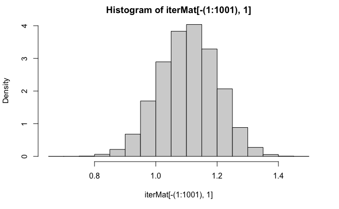

```r
hist(iterMat[-(1:1001),1],freq=FALSE)
```

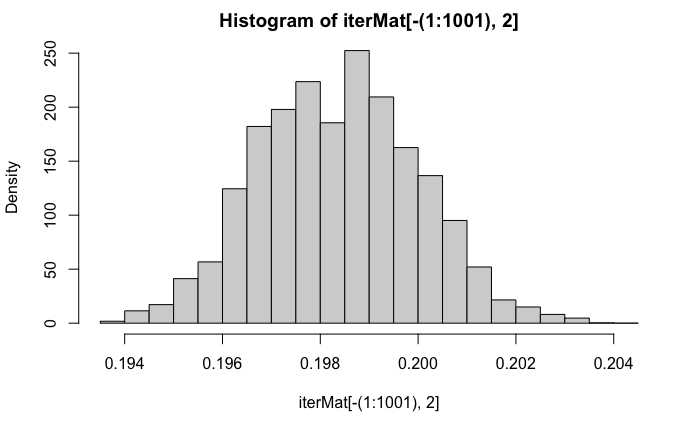

```r
hist(iterMat[-(1:1001),2],freq=FALSE)
```

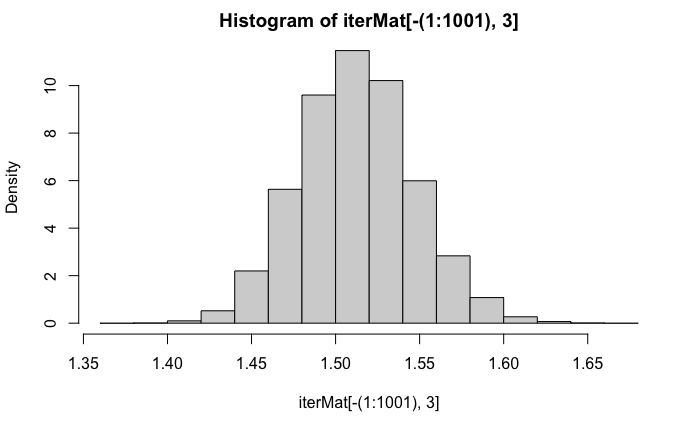

```r
hist(iterMat[-(1:1001),3],freq=FALSE)
```

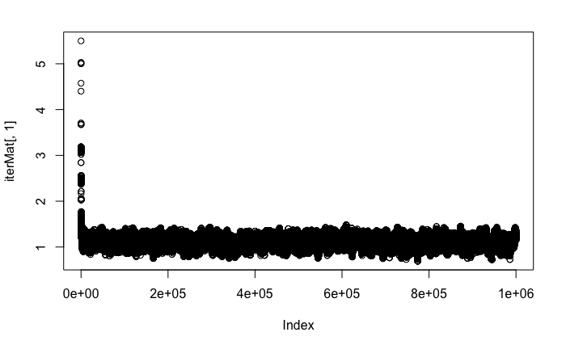

```r
plot(iterMat[,1])
```

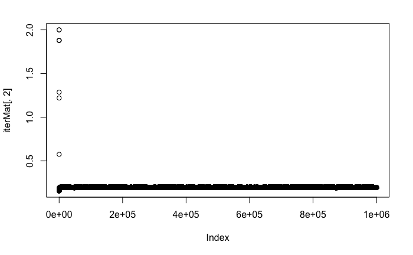

```r
plot(iterMat[,2])
```

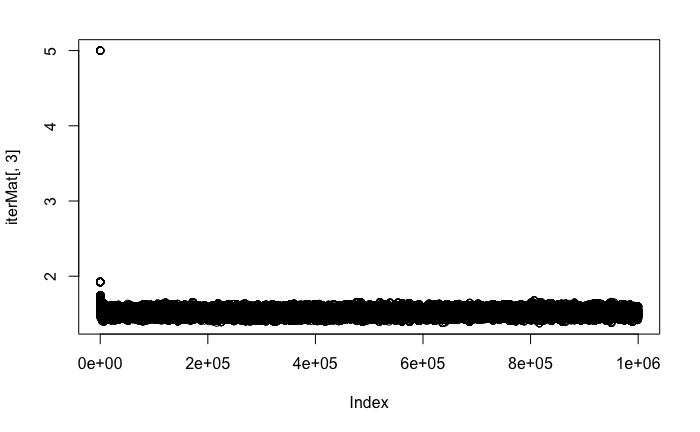

```r
plot(iterMat[,3])
```

Scratch code ######################################################################

```r
normalProposal<-function(currentValue,sd=2){

  proposedValue<-rnorm(1,mean=currentValue,sd)

  return(proposedValue)
}
```

```r
logNormalProposal<-function(currentValue,sd=0.5){

  proposedValue<-rlnorm(1,mean=log(currentValue),sd)

  return(proposedValue)
}
```

```r
nlpRegressionLinear<-function(parmVector,weightDat,heightDat,priorVect,print=F){

  intercept<-parmVector[1]
  B<-parmVector[2]
  mySD<-parmVector[3]

  w<-weightDat
  h<-heightDat
  mu<-intercept + B*h

  nllik<- -sum(dnorm(x=w,mean=mu,sd=mySD,log=TRUE))

  meanNormalPrior<-priorVect[1]
  sdNormalPrior<-priorVect[2]
  expPrior<-priorVect[3]

  nlPriorIntercept<- -dnorm(intercept, mean =  meanNormalPrior, sd = sdNormalPrior, log=TRUE)
  nlPriorB<- -dnorm(B, mean =  meanNormalPrior, sd = sdNormalPrior, log=TRUE)
  nlPriorSD<- -dexp(mySD, rate=expPrior, log=TRUE)

  nllPosterior<- nllik + nlPriorIntercept + nlPriorB + nlPriorSD
   # browser() # for debugging
  if (print) cat("nllik= ",nllik,sep=" ", "nllPosterior= ", nllPosterior,fill=T)
  return(nllPosterior)}
```

```r
nllRegressionLinear<-function(parmVector,weightDat,heightDat,print=F){

  intercept<-parmVector[1]
  B<-parmVector[2]
  mySD<-parmVector[3]

  w<-weightDat
  h<-heightDat
  mu<-intercept + B*h

  nllik<- -sum(dnorm(x=w,mean=mu,sd=mySD,log=TRUE))

  if (print) cat("nllik= ",nllik,sep=" ",fill=T)
  return(nllik)}
```

```r
prior_reg<-function(pars,priorVector)
{
    a<-pars[1]          #intercept
    b<-pars[2]          #slope
    sd<-pars[3]    #error

    prior_a<-dnorm(a,0,100,log=TRUE)     ## non-informative (flat) priors on all
    prior_b<-dnorm(b,0,100,log=TRUE)     ## parameters.
    prior_sd<-dgamma(sd,1,1/100,log=TRUE)

    return(prior_a + prior_b + prior_sd)
}
```

Belwo is the code that we use to find the Maximum Likelihood Estimate (MLE) for the linear model: w ~ normal(mu, sd) mu<- intercept + B*height We have three parameters to estimate: intercept, B, and sd

```r
parVecLinear<-c(0.1,0.1,10) # Initial parameter values
outRegLinear<-optim(par=parVecLinear,fn=nllRegressionLinear,method="L-BFGS-B",lower=c(-Inf,-Inf, 0.01),upper=c(Inf,Inf, Inf), weightDat=myData$weight, heightDat=myData$height,print=F)
outRegLinear$par
outRegLinear$value
```

[output not shown]

```r
lmFit<-lm(weight~height,data=myData)
summary(lmFit)
```

[output not shown]

MXIMUM A POSTERIOR (MAP) PROBABILITY ESIMATE: This is what the quap function in the Rethinking library uses to estimate the posterior distribution. In this approach, we just need to modify our likelihood function to include the prior distribution. Recall that the posterior ~ likelihood * prior. Since we are working on the log scale, the likelihood and prior are added together rather than multiplied. So the main change in the function below is that I have added the priors into the calculation, then combine the likelihood and priors to get the posterior density.

```r
nlpRegressionLinear<-function(parmVector,weightDat,heightDat,priorVect,print=F){

  intercept<-parmVector[1]
  B<-parmVector[2]
  mySD<-parmVector[3]

  w<-weightDat
  h<-heightDat
  mu<-intercept + B*h

  nllik<- -sum(dnorm(x=w,mean=mu,sd=mySD,log=TRUE))

  meanNormalPrior<-priorVect[1]
  sdNormalPrior<-priorVect[2]
  expPrior<-priorVect[3]

  nlPriorIntercept<- -dnorm(intercept, mean =  meanNormalPrior, sd = sdNormalPrior, log=TRUE)
  nlPriorB<- -dnorm(B, mean =  meanNormalPrior, sd = sdNormalPrior, log=TRUE)
  nlPriorSD<- -dexp(mySD, rate=expPrior, log=TRUE)

  nllPosterior<- nllik + nlPriorIntercept + nlPriorB + nlPriorSD
   # browser() # for debugging
  if (print) cat("nllik= ",nllik,sep=" ", "nllPosterior= ", nllPosterior,fill=T)
  return(nllPosterior)}
```

Now we use optim to find the MAP just as we did above for the MLE.

```r
parVecLinear<-c(0.1,0.1,10) # Initial parameter values
priorVectLinear<-c(0,10,1) # these are parameter values for the priors
outBayesRegLinear<-optim(par=parVecLinear,fn=nlpRegressionLinear,method="L-BFGS-B",lower=c(-Inf,-Inf, 0.01),upper=c(Inf,Inf, Inf), weightDat=myData$weight, heightDat=myData$height,priorVect=priorVectLinear,print=F)
outBayesRegLinear$par
outBayesRegLinear$value
```

[output not shown]

Finally, let’s compare our fit above to that produced by the quap function within the Rethinking package.

```r
library(rethinking)
lm.qa <- quap(
    alist(
        weight ~ dnorm(mu,sd) ,  # normal likelihood
        sd ~ dexp(1),     # exponential prior
        mu<-intercept + beta*height,
        intercept~dnorm(0,10),
        beta~dnorm(0,10)
    ) ,
    data=list(weight=myData$weight,height=myData$height) )

precis(lm.qa)
```

[output not shown]

Looking a little closer at the quap fit. quap uses the same optim function that we used above and you can access details of the optim fit by examining components of the fit. Note that we are digging deeper here and these components are not normally visible to users, but we are access the slots of the returned object. (No need to worry about this as it is a bit more advanced computational concept.)

```r
lm.qa
slot(lm.qa, 'optim')
```

[output not shown]

Scratch Code #########################################################################################################

```r
parVecLinearMLE<-c(-51.6295921,0.6251449,4.2428686)

nlpRegressionLinear(parVecLinearMLE,weightDat=myData$weight,heightDat=myData$height,priorVectLinear,print=F)
nllRegressionLinear(parVecLinearMLE,weightDat=myData$weight,heightDat=myData$height,print=F)
```

```r
parVecLinearBayes<-c(-42.79,0.57,4.24)
nlpRegressionLinear(parVecLinearBayes,weightDat=myData$weight,heightDat=myData$height,priorVectLinear,print=F)
nllRegressionLinear(parVecLinearBayes,weightDat=myData$weight,heightDat=myData$height,print=F)
```